# Homework 7

Aubrey Pelletier

October 10, 2018

# Creating Fake Data Sets to Explore Hypotheses

#### I am using lizard sprint speed data from the internet that was used for one of previous homeworks I did. It has observations from each lizard, and their sprint speeds. I grabbed the mean and standard deviations from the excel document for the control group, and they had about 40 lizards, so I used that as my sample size to start. The data is attached below if curious.

#### Then, I created a hypothetical treatment to use, if I fed them, I hypothesized that they would run more slowly because they would be fat and slow, so I made my treatment data set have a lower mean, but the same standard deviation.

```r
read.table(file="15q24LizardSprintSpeed.csv")
```

```
##              V1
## 1  lizard,speed
## 2        1,1.43
## 3        1,1.37
## 4        2,1.56
## 5         2,1.3
## 6        3,1.64
## 7        3,1.36
## 8        4,2.13
## 9        4,1.54
## 10       5,1.96
## 11       5,1.82
## 12       6,1.89
## 13       6,1.79
## 14       7,1.72
```

[output cut: 55 more lines]

```r
library(tidyverse)
nObs <- 40 #number of observations

LizSpeedControl <- rnorm(n=nObs, mean=2.14, sd=.44)
LizSpeedTreat <- rnorm(n=nObs, mean=1.98, sd=.44)

name <- ("Control")
name1 <- ("Treat")
TreatCont <- rep(name, nObs)
TreatTreat <- rep(name1, nObs)
TreatVec <- c(TreatCont, TreatTreat)
print(TreatVec)
```

```
##  [1] "Control" "Control" "Control" "Control" "Control" "Control" "Control"
##  [8] "Control" "Control" "Control" "Control" "Control" "Control" "Control"
## [15] "Control" "Control" "Control" "Control" "Control" "Control" "Control"
## [22] "Control" "Control" "Control" "Control" "Control" "Control" "Control"
## [29] "Control" "Control" "Control" "Control" "Control" "Control" "Control"
## [36] "Control" "Control" "Control" "Control" "Control" "Treat"   "Treat"
## [43] "Treat"   "Treat"   "Treat"   "Treat"   "Treat"   "Treat"   "Treat"
## [50] "Treat"   "Treat"   "Treat"   "Treat"   "Treat"   "Treat"   "Treat"
## [57] "Treat"   "Treat"   "Treat"   "Treat"   "Treat"   "Treat"   "Treat"
## [64] "Treat"   "Treat"   "Treat"   "Treat"   "Treat"   "Treat"   "Treat"
## [71] "Treat"   "Treat"   "Treat"   "Treat"   "Treat"   "Treat"   "Treat"
## [78] "Treat"   "Treat"   "Treat"
```

```r
TreatVec <- c(rep(name, nObs), rep(name1, nObs)) #alternate code to get TreatVec
print(TreatVec)
```

```
##  [1] "Control" "Control" "Control" "Control" "Control" "Control" "Control"
##  [8] "Control" "Control" "Control" "Control" "Control" "Control" "Control"
## [15] "Control" "Control" "Control" "Control" "Control" "Control" "Control"
## [22] "Control" "Control" "Control" "Control" "Control" "Control" "Control"
## [29] "Control" "Control" "Control" "Control" "Control" "Control" "Control"
## [36] "Control" "Control" "Control" "Control" "Control" "Treat"   "Treat"
## [43] "Treat"   "Treat"   "Treat"   "Treat"   "Treat"   "Treat"   "Treat"
## [50] "Treat"   "Treat"   "Treat"   "Treat"   "Treat"   "Treat"   "Treat"
## [57] "Treat"   "Treat"   "Treat"   "Treat"   "Treat"   "Treat"   "Treat"
## [64] "Treat"   "Treat"   "Treat"   "Treat"   "Treat"   "Treat"   "Treat"
## [71] "Treat"   "Treat"   "Treat"   "Treat"   "Treat"   "Treat"   "Treat"
## [78] "Treat"   "Treat"   "Treat"
```

```r
Speeds <- c(LizSpeedControl, LizSpeedTreat)


ID <-seq_len(nObs)

LizData <- data.frame(ID,TreatVec,Speeds)
print(data)
```

[output not shown]

[output cut: 112 more lines]

[output not shown]

```r
str(data)
```

```
## function (..., list = character(), package = NULL, lib.loc = NULL,
##     verbose = getOption("verbose"), envir = .GlobalEnv)
```

```r
#Using ANOVA model because we have a categorical and continuous variable
ANOmodel <- aov(Speeds~TreatVec, data=LizData) #Speeds are a function of TreatVec(treatment)
print(ANOmodel)
```

```
## Call:
##    aov(formula = Speeds ~ TreatVec, data = LizData)
##
## Terms:
##                  TreatVec Residuals
## Sum of Squares   0.001383 16.033602
## Deg. of Freedom         1        78
##
## Residual standard error: 0.4533861
## Estimated effects may be unbalanced
```

```r
print(summary(ANOmodel))
```

```
##             Df Sum Sq Mean Sq F value Pr(>F)
## TreatVec     1  0.001 0.00138   0.007  0.935
## Residuals   78 16.034 0.20556
```

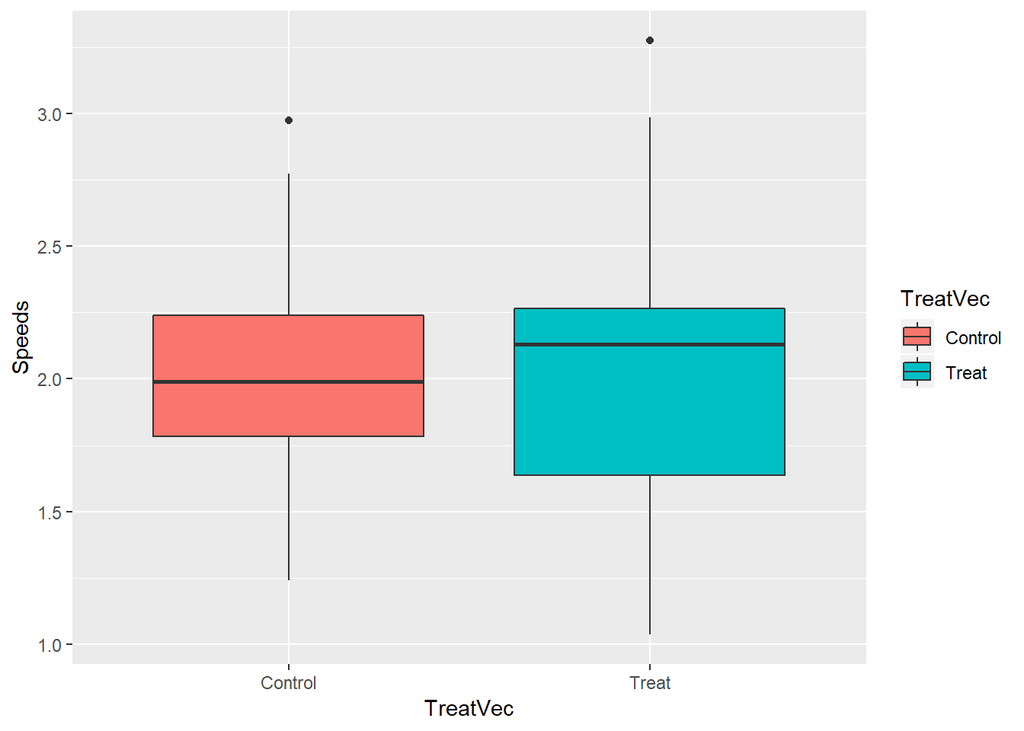

```r
# Basic ggplot of ANOVA data

ANOPlot <- ggplot(data=LizData,
                  aes(x=TreatVec, y=Speeds,
                      fill = TreatVec)) +
  geom_boxplot()
print(ANOPlot)
```

### Step 5: Running the analysis switches frequently between significant and not significant, the p-value is very variable.

```r
nObs <- 40 #number of observations

LizSpeedControl <- rnorm(n=nObs, mean=2.14, sd=.44)
LizSpeedTreat <- rnorm(n=nObs, mean=1.9, sd=.44)

name <- ("Control")
name1 <- ("Treat")
TreatCont <- rep(name, nObs)
TreatTreat <- rep(name1, nObs)
TreatVec <- c(TreatCont, TreatTreat)
print(TreatVec)
```

```
##  [1] "Control" "Control" "Control" "Control" "Control" "Control" "Control"
##  [8] "Control" "Control" "Control" "Control" "Control" "Control" "Control"
## [15] "Control" "Control" "Control" "Control" "Control" "Control" "Control"
## [22] "Control" "Control" "Control" "Control" "Control" "Control" "Control"
## [29] "Control" "Control" "Control" "Control" "Control" "Control" "Control"
## [36] "Control" "Control" "Control" "Control" "Control" "Treat"   "Treat"
## [43] "Treat"   "Treat"   "Treat"   "Treat"   "Treat"   "Treat"   "Treat"
## [50] "Treat"   "Treat"   "Treat"   "Treat"   "Treat"   "Treat"   "Treat"
## [57] "Treat"   "Treat"   "Treat"   "Treat"   "Treat"   "Treat"   "Treat"
## [64] "Treat"   "Treat"   "Treat"   "Treat"   "Treat"   "Treat"   "Treat"
## [71] "Treat"   "Treat"   "Treat"   "Treat"   "Treat"   "Treat"   "Treat"
## [78] "Treat"   "Treat"   "Treat"
```

```r
TreatVec <- c(rep(name, nObs), rep(name1, nObs)) #alternate code to get TreatVec
print(TreatVec)
```

```
##  [1] "Control" "Control" "Control" "Control" "Control" "Control" "Control"
##  [8] "Control" "Control" "Control" "Control" "Control" "Control" "Control"
## [15] "Control" "Control" "Control" "Control" "Control" "Control" "Control"
## [22] "Control" "Control" "Control" "Control" "Control" "Control" "Control"
## [29] "Control" "Control" "Control" "Control" "Control" "Control" "Control"
## [36] "Control" "Control" "Control" "Control" "Control" "Treat"   "Treat"
## [43] "Treat"   "Treat"   "Treat"   "Treat"   "Treat"   "Treat"   "Treat"
## [50] "Treat"   "Treat"   "Treat"   "Treat"   "Treat"   "Treat"   "Treat"
## [57] "Treat"   "Treat"   "Treat"   "Treat"   "Treat"   "Treat"   "Treat"
## [64] "Treat"   "Treat"   "Treat"   "Treat"   "Treat"   "Treat"   "Treat"
## [71] "Treat"   "Treat"   "Treat"   "Treat"   "Treat"   "Treat"   "Treat"
## [78] "Treat"   "Treat"   "Treat"
```

```r
Speeds <- c(LizSpeedControl, LizSpeedTreat)


ID <-seq_len(nObs)

LizData <- data.frame(ID,TreatVec,Speeds)
print(data)
```

[output not shown]

[output cut: 112 more lines]

[output not shown]

```r
str(data)
```

```
## function (..., list = character(), package = NULL, lib.loc = NULL,
##     verbose = getOption("verbose"), envir = .GlobalEnv)
```

```r
#Using ANOVA model because we have a categorical and continuous variable
ANOmodel <- aov(Speeds~TreatVec, data=LizData) #Speeds are a function of TreatVec(treatment)
print(ANOmodel)
```

```
## Call:
##    aov(formula = Speeds ~ TreatVec, data = LizData)
##
## Terms:
##                  TreatVec Residuals
## Sum of Squares   3.075906 12.453407
## Deg. of Freedom         1        78
##
## Residual standard error: 0.3995736
## Estimated effects may be unbalanced
```

```r
print(summary(ANOmodel))
```

```
##             Df Sum Sq Mean Sq F value   Pr(>F)
## TreatVec     1  3.076  3.0759   19.27 3.53e-05 ***
## Residuals   78 12.453  0.1597
## ---
## Signif. codes:  0 '***' 0.001 '**' 0.01 '*' 0.05 '.' 0.1 ' ' 1
```

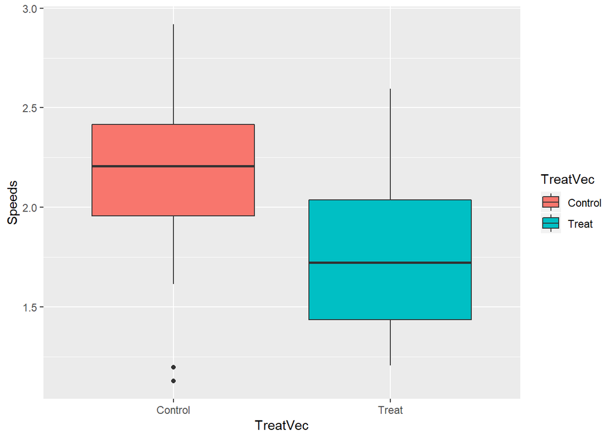

```r
# Basic ggplot of ANOVA data

ANOPlot <- ggplot(data=LizData,
                  aes(x=TreatVec, y=Speeds,
                      fill = TreatVec)) +
  geom_boxplot()
print(ANOPlot)
```

### 6: Around 1.9 as the treatment value mean is when it starts becoming very variable between significant and non-significant results

# 7: What is the minimum sample size you would need in order to detect a statistically significant effect?

#### I lowered the mean of the treatment speeds to 1.8, because that was almost always significant, so that I could look separately at the sample size (nObs) to see where that came into play

```r
nObs <- 5 #number of observations

LizSpeedControl <- rnorm(n=nObs, mean=2.14, sd=.44)
LizSpeedTreat <- rnorm(n=nObs, mean=1.8, sd=.44)

name <- ("Control")
name1 <- ("Treat")
TreatCont <- rep(name, nObs)
TreatTreat <- rep(name1, nObs)
TreatVec <- c(TreatCont, TreatTreat)
print(TreatVec)
```

```
##  [1] "Control" "Control" "Control" "Control" "Control" "Treat"   "Treat"
##  [8] "Treat"   "Treat"   "Treat"
```

```r
TreatVec <- c(rep(name, nObs), rep(name1, nObs)) #alternate code to get TreatVec
print(TreatVec)
```

```
##  [1] "Control" "Control" "Control" "Control" "Control" "Treat"   "Treat"
##  [8] "Treat"   "Treat"   "Treat"
```

```r
Speeds <- c(LizSpeedControl, LizSpeedTreat)


ID <-seq_len(nObs)

LizData <- data.frame(ID,TreatVec,Speeds)
print(data)
```

[output not shown]

[output cut: 112 more lines]

[output not shown]

```r
str(data)
```

```
## function (..., list = character(), package = NULL, lib.loc = NULL,
##     verbose = getOption("verbose"), envir = .GlobalEnv)
```

```r
#Using ANOVA model because we have a categorical and continuous variable
ANOmodel <- aov(Speeds~TreatVec, data=LizData) #Speeds are a function of TreatVec(treatment)
print(ANOmodel)
```

```
## Call:
##    aov(formula = Speeds ~ TreatVec, data = LizData)
##
## Terms:
##                  TreatVec Residuals
## Sum of Squares  0.0013684 1.2668166
## Deg. of Freedom         1         8
##
## Residual standard error: 0.3979348
## Estimated effects may be unbalanced
```

```r
print(summary(ANOmodel))
```

```
##             Df Sum Sq Mean Sq F value Pr(>F)
## TreatVec     1 0.0014 0.00137   0.009  0.928
## Residuals    8 1.2668 0.15835
```

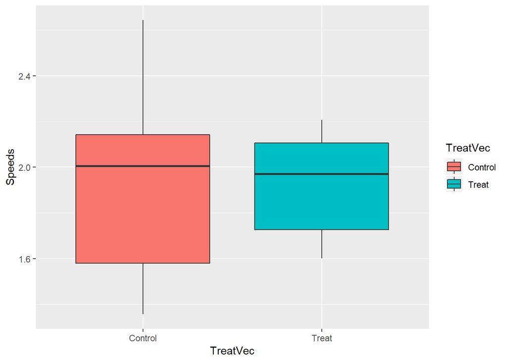

```r
# Basic ggplot of ANOVA data

ANOPlot <- ggplot(data=LizData,
                  aes(x=TreatVec, y=Speeds,
                      fill = TreatVec)) +
  geom_boxplot()
print(ANOPlot)
```

#### At nObs=25 there starts to be some variation - the results are still significant a majority of the time, but not always. At n=10, it seems to be about 50-50, and at n=5, they don’t seem to be significant most of the time